# R Notebook

**Principles of Data Visualization and Introduction to ggplot2**

I have provided you with data about the 5,000 fastest growing companies in the US, as compiled by Inc. magazine. lets read this in:

```r
inc <- read.csv("https://raw.githubusercontent.com/charleyferrari/CUNY_DATA_608/master/module1/Data/inc5000_data.csv", header= TRUE)
```

And lets preview this data:

```r
head(inc)
```

```
##   Rank                         Name Growth_Rate   Revenue
## 1    1                         Fuhu      421.48 1.179e+08
## 2    2        FederalConference.com      248.31 4.960e+07
## 3    3                The HCI Group      245.45 2.550e+07
## 4    4                      Bridger      233.08 1.900e+09
## 5    5                       DataXu      213.37 8.700e+07
## 6    6 MileStone Community Builders      179.38 4.570e+07
##                       Industry Employees         City State
## 1 Consumer Products & Services       104   El Segundo    CA
## 2          Government Services        51     Dumfries    VA
## 3                       Health       132 Jacksonville    FL
## 4                       Energy        50      Addison    TX
## 5      Advertising & Marketing       220       Boston    MA
## 6                  Real Estate        63       Austin    TX
```

```r
summary(inc)
```

```
##       Rank          Name            Growth_Rate         Revenue
##  Min.   :   1   Length:5001        Min.   :  0.340   Min.   :2.000e+06
##  1st Qu.:1252   Class :character   1st Qu.:  0.770   1st Qu.:5.100e+06
##  Median :2502   Mode  :character   Median :  1.420   Median :1.090e+07
##  Mean   :2502                      Mean   :  4.612   Mean   :4.822e+07
##  3rd Qu.:3751                      3rd Qu.:  3.290   3rd Qu.:2.860e+07
##  Max.   :5000                      Max.   :421.480   Max.   :1.010e+10
##
##    Industry           Employees           City              State
##  Length:5001        Min.   :    1.0   Length:5001        Length:5001
##  Class :character   1st Qu.:   25.0   Class :character   Class :character
##  Mode  :character   Median :   53.0   Mode  :character   Mode  :character
##                     Mean   :  232.7
##                     3rd Qu.:  132.0
##                     Max.   :66803.0
##                     NA's   :12
```

Think a bit on what these summaries mean. Use the space below to add some more relevant non-visual exploratory information you think helps you understand this data:

### Additional Non-Visual Exploratory Information

The `Industry` variable looks like that it could converted into a factor. For many of these companies, many of the industries probably overlap with one another, so it would be interesting to see how many of these 5,000 companies share the same industry. We can also determine the state that holds the greatest number of companies by converting the “State” variable to a factor as well.

```r
inc$Industry <- as.factor(inc$Industry)
inc$State <- as.factor(inc$State)
summary(inc)
```

```
##       Rank          Name            Growth_Rate         Revenue
##  Min.   :   1   Length:5001        Min.   :  0.340   Min.   :2.000e+06
##  1st Qu.:1252   Class :character   1st Qu.:  0.770   1st Qu.:5.100e+06
##  Median :2502   Mode  :character   Median :  1.420   Median :1.090e+07
##  Mean   :2502                      Mean   :  4.612   Mean   :4.822e+07
##  3rd Qu.:3751                      3rd Qu.:  3.290   3rd Qu.:2.860e+07
##  Max.   :5000                      Max.   :421.480   Max.   :1.010e+10
##
##                          Industry      Employees           City
##  IT Services                 : 733   Min.   :    1.0   Length:5001
##  Business Products & Services: 482   1st Qu.:   25.0   Class :character
##  Advertising & Marketing     : 471   Median :   53.0   Mode  :character
##  Health                      : 355   Mean   :  232.7
##  Software                    : 342   3rd Qu.:  132.0
##  Financial Services          : 260   Max.   :66803.0
##  (Other)                     :2358   NA's   :12
##      State
##  CA     : 701
##  TX     : 387
##  NY     : 311
##  VA     : 283
##  FL     : 282
##  IL     : 273
##  (Other):2764
```

The output above shows us that out of 5,000 companies, the industry with the most companies is IT services, and California holds the greater number of companies within the dataset.

The summary output also reveals that 12 of these companies have an employee count of NA, so it would also be interesting to see which of the 5,000 companies have an employee count of NA. We can also sort by revenue as well.

```r
inc %>% filter(is.na(Employees)) %>% arrange(desc(Revenue))
```

```
##    Rank                             Name Growth_Rate   Revenue
## 1  3001       Heartland Business Systems        1.12 156300000
## 2  1064                         Popchips        3.98  93300000
## 3  3978                             SSEC        0.68  80400000
## 4  1124                       Vocalocity        3.72  42900000
## 5  2197              JeffreyM Consulting        1.68  12100000
## 6  2743               Excalibur Exhibits        1.27   9900000
## 7  4566                         Oakbrook        0.48   8900000
## 8  1653                     Higher Logic        2.36   6000000
## 9  4968                   Popcorn Palace        0.35   5500000
## 10 1686      Global Communications Group        2.30   3600000
## 11 4112 Carolinas Home Medical Equipment        0.64   3300000
## 12  183           First Flight Solutions       22.32   2700000
##                        Industry Employees          City State
## 1                   IT Services        NA  Little Chute    WI
## 2               Food & Beverage        NA San Francisco    CA
## 3                 Manufacturing        NA       Horsham    PA
## 4            Telecommunications        NA       Atlanta    GA
## 5  Business Products & Services        NA      Bellevue    WA
## 6  Business Products & Services        NA       houston    TX
## 7                   Real Estate        NA       Madison    WI
## 8                      Software        NA    Washington    DC
## 9               Food & Beverage        NA Schiller Park    IL
## 10           Telecommunications        NA     Englewood    CO
## 11                       Health        NA      Matthews    NC
## 12   Logistics & Transportation        NA  Emerald Isle    NC
```

The output above shows us that Heartland Business Systems, which has no employee count, has a revenue amount of 156,300,000. An interesting thing to point out is that the output above reveals that the company with the least amount of revenue and an employee count of NA has a growth rate that is an order of magnitude higher than the rest of the growth rates.

## Question 1

Create a graph that shows the distribution of companies in the dataset by State (ie how many are in each state). There are a lot of States, so consider which axis you should use. This visualization is ultimately going to be consumed on a ‘portrait’ oriented screen (ie taller than wide), which should further guide your layout choices.

[figure not shown]

```r
ggplot(inc, aes(x = fct_infreq(State))) +
  geom_bar() +
  coord_flip() +
  labs(x = "Count", y = "State")
```

## Quesiton 2

Lets dig in on the state with the 3rd most companies in the data set. Imagine you work for the state and are interested in how many people are employed by companies in different industries. Create a plot that shows the average and/or median employment by industry for companies in this state (only use cases with full data, use R’s `complete.cases()` function.) In addition to this, your graph should show how variable the ranges are, and you should deal with outliers.

### Question 2 Answer

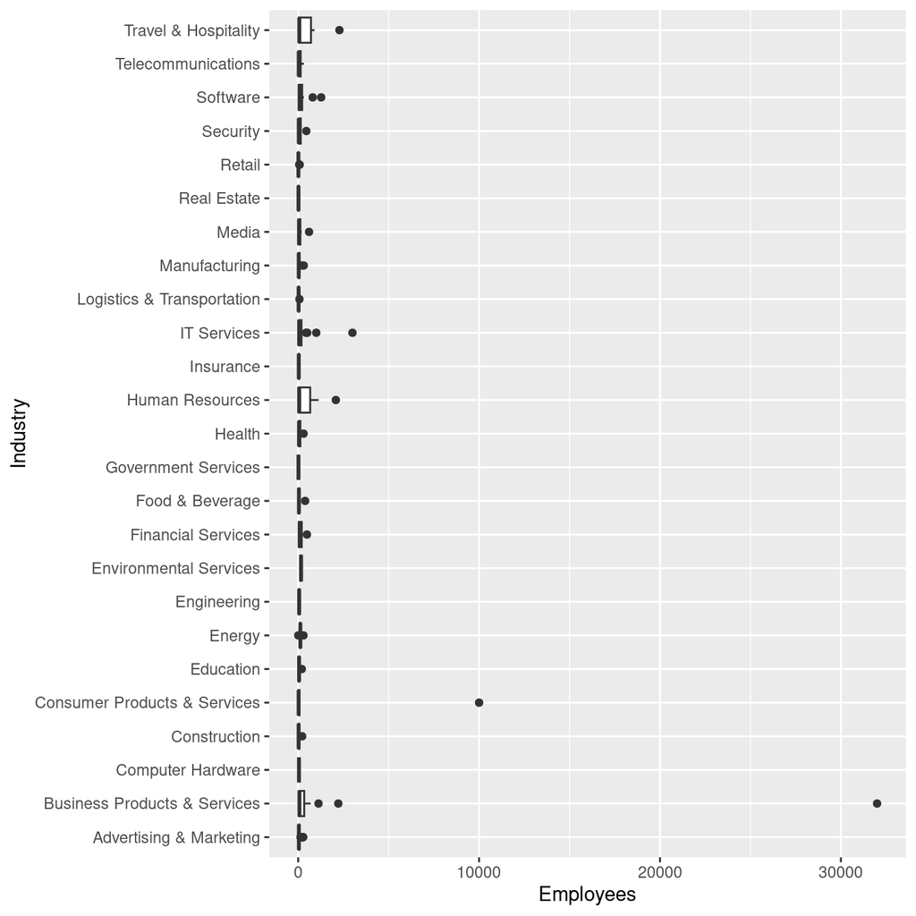

```r
ny_data <- inc %>%
  filter(State == "NY" & complete.cases(.)) %>%
  select(Employees, Industry)

ggplot(data = ny_data, mapping = aes(x = Industry, y = Employees)) +
  coord_flip() +
  geom_boxplot()
```

The output above shows us there are significant outliers for “Consumer Products & Services” and for “Business Products and Servies”. The outliers are so significant that the boxplots themselves are extremely small. Therefore, we are going to remove outliers that are 1.5 times the interquartile range greater than the 3rd quantile or 1.5 times the interquartile range less than the first quantile [1].

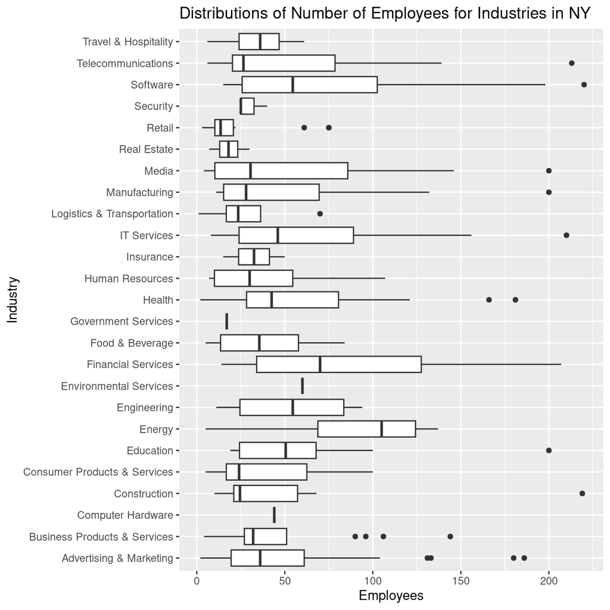

```r
ny_data_outliers_removed <- ny_data %>%
  group_by(Industry) %>%
  subset(Employees > (quantile(Employees, 0.25) - 1.5*IQR(Employees)) & Employees < quantile(Employees, 0.75) + 1.5*IQR(Employees))

ggplot(data = ny_data_outliers_removed, mapping = aes(x = Industry, y = Employees)) +
  coord_flip() +
  geom_boxplot() +
  ggtitle("Distributions of Number of Employees for Industries in NY")
```

## Question 3

Now imagine you work for an investor and want to see which industries generate the most revenue per employee. Create a chart that makes this information clear. Once again, the distribution per industry should be shown.

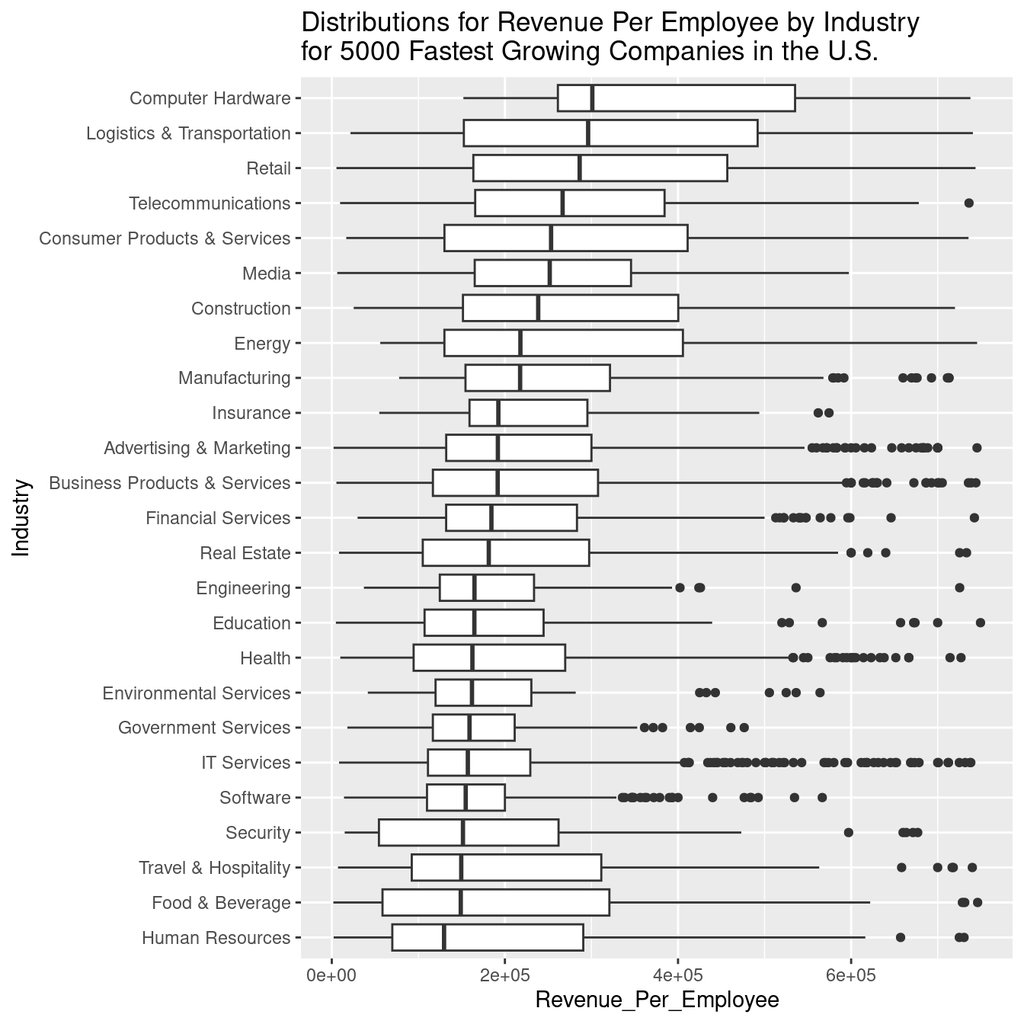

```r
inc$Revenue_Per_Employee <- round(inc$Revenue/inc$Employees, digits = 2)

inc_revenue_per_employee_outliers_removed <- inc %>%
  drop_na(Revenue_Per_Employee) %>%
  group_by(Industry) %>%
  subset(Revenue_Per_Employee > (quantile(Revenue_Per_Employee, 0.25) - 1.5*IQR(Revenue_Per_Employee)) & Revenue_Per_Employee < quantile(Revenue_Per_Employee, 0.75) + 1.5*IQR(Revenue_Per_Employee))

group_ordered <- with(inc_revenue_per_employee_outliers_removed,                       # Order boxes by median
                      reorder(Industry,
                              Revenue_Per_Employee,
                              median))

inc_revenue_per_employee_outliers_removed$Industry <- factor(inc_revenue_per_employee_outliers_removed$Industry,
                                                             levels = levels(group_ordered))
ggplot(data = inc_revenue_per_employee_outliers_removed, mapping = aes(x = Industry, y = Revenue_Per_Employee)) +
  coord_flip() +
  geom_boxplot() +
  ggtitle("Distributions for Revenue Per Employee by Industry \nfor 5000 Fastest Growing Companies in the U.S.")
```

By sorting by the median[2], we can see in the output above that “Computer Hardware’ generates the most revenue per employee.

## References

[1] https://www.statology.org/remove-outliers-r/

[2] https://statisticsglobe.com/sort-boxplot-median-r